# Programming Assignment:

## Готовим LDA по рецептам

Как вы уже знаете, в тематическом моделировании делается предположение о том, что для определения тематики порядок слов в документе не важен; об этом гласит гипотеза «мешка слов». Сегодня мы будем работать с несколько нестандартной для тематического моделирования коллекцией, которую можно назвать «мешком ингредиентов», потому что на состоит из рецептов блюд разных кухонь. Тематические модели ищут слова, которые часто вместе встречаются в документах, и составляют из них темы. Мы попробуем применить эту идею к рецептам и найти кулинарные «темы». Эта коллекция хороша тем, что не требует предобработки. Кроме того, эта задача достаточно наглядно иллюстрирует принцип работы тематических моделей.

Для выполнения заданий, помимо часто используемых в курсе библиотек, потребуются модули *json* и *gensim*. Первый входит в дистрибутив Anaconda, второй можно поставить командой

*pip install gensim*

Построение модели занимает некоторое время. На ноутбуке с процессором Intel Core i7 и тактовой частотой 2400 МГц на построение одной модели уходит менее 10 минут.

### Загрузка данных

Коллекция дана в json-формате: для каждого рецепта известны его id, кухня (cuisine) и список ингредиентов, в него входящих. Загрузить данные можно с помощью модуля json (он входит в дистрибутив Anaconda):

```python
import json
```

```python
with open("recipes.json") as f:
    recipes = json.load(f)
```

```python
print recipes[0]
print '\n', 'размер recipes =', len(recipes)
```

```
{u'cuisine': u'greek', u'id': 10259, u'ingredients': [u'romaine lettuce', u'black olives', u'grape tomatoes', u'garlic', u'pepper', u'purple onion', u'seasoning', u'garbanzo beans', u'feta cheese crumbles']}

размер recipes = 39774
```

### Составление корпуса

```python
from gensim import corpora, models
import numpy as np
```

```python
import numpy
numpy.__version__
```

```
'1.11.3'
```

Наша коллекция небольшая, и целиком помещается в оперативную память. Gensim может работать с такими данными и не требует их сохранения на диск в специальном формате. Для этого коллекция должна быть представлена в виде списка списков, каждый внутренний список соответствует отдельному документу и состоит из его слов. Пример коллекции из двух документов:

[["hello", "world"], ["programming", "in", "python"]]

Преобразуем наши данные в такой формат, а затем создадим объекты corpus и dictionary, с которыми будет работать модель.

```python
texts = [recipe["ingredients"] for recipe in recipes]
dictionary = corpora.Dictionary(texts)   # составляем словарь
corpus = [dictionary.doc2bow(text) for text in texts]  # составляем корпус документов
```

```python
print texts[0]
print corpus[0]
```

```
[u'romaine lettuce', u'black olives', u'grape tomatoes', u'garlic', u'pepper', u'purple onion', u'seasoning', u'garbanzo beans', u'feta cheese crumbles']
[(0, 1), (1, 1), (2, 1), (3, 1), (4, 1), (5, 1), (6, 1), (7, 1), (8, 1)]
```

```python
print dictionary
```

```
Dictionary(6714 unique tokens: [u'low-sodium fat-free chicken broth', u'sweetened coconut', u'baking chocolate', u'egg roll wrappers', u'bottled low sodium salsa']...)
```

```python
for i in range(9):
    print dictionary[i]
```

```
pepper
seasoning
garbanzo beans
grape tomatoes
garlic
black olives
feta cheese crumbles
romaine lettuce
purple onion
```

```python
for text in texts[0]:
    print dictionary.token2id[text]
```

```
7
5
3
4
0
8
1
2
6
```

```python
print dictionary
```

```
Dictionary(6714 unique tokens: [u'low-sodium fat-free chicken broth', u'sweetened coconut', u'baking chocolate', u'egg roll wrappers', u'bottled low sodium salsa']...)
```

У объекта dictionary есть полезная переменная dictionary.token2id, позволяющая находить соответствие между ингредиентами и их индексами.

```python
dictionary.token2id
```

[output not shown]

[output cut: 946 more lines]

```
 u'poppy seeds': 1703,
 u'reduced sodium smoked ham': 6369,
 u'pasta rotel': 1268,
 u'ragu old world style sweet tomato basil pasta sauc': 5169,
 u'tortellini': 2415,
 u'masur dal': 3217,
 u'filet mignon': 4381,
 u'skinless snapper fillets': 6630,
 u'yellow bell pepper': 523,
 u'pita bread rounds': 689,
 u'whole wheat spaghetti': 1810,
 u'spaghetti': 193,
 u'mian': 6437,
 u'bow-tie pasta': 1445,
 ...}
```

```python
dictionary.token2id['romaine lettuce']
```

```
7
```

```python
dictionary.id2token[7]
```

```
u'romaine lettuce'
```

### Обучение модели

Вам может понадобиться [документация](https://radimrehurek.com/gensim/models/ldamodel.html) LDA в gensim.

**Задание 1.** Обучите модель LDA с 40 темами, установив количество проходов по коллекции 5 и оставив остальные параметры по умолчанию.

Затем вызовите метод модели *show_topics*, указав количество тем 40 и количество токенов 10, и сохраните результат (топы ингредиентов в темах) в отдельную переменную. Если при вызове метода *show_topics* указать параметр *formatted=True*, то топы ингредиентов будет удобно выводить на печать, если *formatted=False*, будет удобно работать со списком программно. Выведите топы на печать, рассмотрите темы, а затем ответьте на вопрос:

Сколько раз ингредиенты "salt", "sugar", "water", "mushrooms", "chicken", "eggs" встретились среди топов-10 всех 40 тем? При ответе **не нужно** учитывать составные ингредиенты, например, "hot water".

Передайте 6 чисел в функцию save_answers1 и загрузите сгенерированный файл в форму.

У gensim нет возможности фиксировать случайное приближение через параметры метода, но библиотека использует numpy для инициализации матриц. Поэтому, по утверждению автора библиотеки, фиксировать случайное приближение нужно командой, которая написана в следующей ячейке. **Перед строкой кода с построением модели обязательно вставляйте указанную строку фиксации random.seed.**

```python
%%time
np.random.seed(76543)
# здесь код для построения модели:

lda = models.ldamodel.LdaModel(corpus, num_topics=40, passes=5)
```

```
Wall time: 5min 35s
```

```python
lda.show_topics(num_topics=40, num_words=10, formatted=True)
```

```
[(0,
  '0.083*"17" + 0.080*"116" + 0.079*"100" + 0.064*"54" + 0.064*"279" + 0.035*"119" + 0.034*"307" + 0.034*"29" + 0.033*"38" + 0.032*"12"'),
 (1,
  '0.130*"195" + 0.077*"45" + 0.052*"178" + 0.043*"124" + 0.040*"211" + 0.039*"29" + 0.037*"958" + 0.031*"705" + 0.029*"17" + 0.026*"1493"'),
 (2,
  '0.066*"770" + 0.047*"830" + 0.046*"1338" + 0.045*"480" + 0.044*"3" + 0.039*"1637" + 0.035*"816" + 0.033*"806" + 0.030*"117" + 0.030*"1201"'),
 (3,
  '0.117*"41" + 0.112*"207" + 0.081*"17" + 0.050*"383" + 0.049*"0" + 0.048*"45" + 0.046*"155" + 0.030*"29" + 0.029*"425" + 0.029*"397"'),
 (4,
  '0.061*"200" + 0.057*"20" + 0.055*"17" + 0.054*"39" + 0.039*"45" + 0.034*"348" + 0.032*"183" + 0.030*"236" + 0.027*"216" + 0.026*"12"'),
 (5,
  '0.073*"46" + 0.053*"17" + 0.048*"113" + 0.041*"183" + 0.038*"54" + 0.035*"45" + 0.033*"4" + 0.023*"39" + 0.022*"100" + 0.020*"127"'),
 (6,
  '0.113*"51" + 0.087*"366" + 0.056*"310" + 0.052*"494" + 0.048*"387" + 0.046*"541" + 0.034*"373" + 0.033*"249" + 0.031*"52" + 0.030*"511"'),
 (7,
  '0.082*"557" + 0.078*"76" + 0.078*"112" + 0.075*"54" + 0.046*"17" + 0.045*"358" + 0.033*"100" + 0.031*"190" + 0.028*"193" + 0.028*"141"'),
 (8,
  '0.089*"23" + 0.059*"471" + 0.057*"17" + 0.057*"456" + 0.051*"29" + 0.049*"352" + 0.041*"1286" + 0.033*"1090" + 0.027*"1255" + 0.026*"1040"'),
 (9,
  '0.075*"83" + 0.074*"45" + 0.065*"4" + 0.058*"478" + 0.055*"17" + 0.053*"229" + 0.050*"321" + 0.041*"230" + 0.040*"345" + 0.036*"54"'),
 (10,
  '0.040*"12" + 0.038*"990" + 0.037*"204" + 0.037*"504" + 0.032*"114" + 0.032*"21" + 0.029*"514" + 0.028*"624" + 0.025*"17" + 0.025*"117"'),
 (11,
  '0.066*"58" + 0.064*"17" + 0.049*"110" + 0.040*"74" + 0.034*"4" + 0.034*"8" + 0.033*"54" + 0.032*"839" + 0.031*"111" + 0.029*"46"'),
 (12,
  '0.102*"536" + 0.068*"569" + 0.047*"1044" + 0.044*"530" + 0.039*"7" + 0.038*"1743" + 0.036*"600" + 0.033*"876" + 0.031*"8" + 0.029*"1043"'),
 (13,
  '0.083*"272" + 0.056*"577" + 0.049*"246" + 0.047*"201" + 0.038*"520" + 0.038*"33" + 0.033*"231" + 0.030*"46" + 0.024*"69" + 0.024*"71"'),
 (14,
  '0.074*"432" + 0.065*"128" + 0.051*"431" + 0.048*"228" + 0.046*"524" + 0.043*"864" + 0.043*"48" + 0.036*"622" + 0.036*"29" + 0.028*"819"'),
 (15,
  '0.091*"318" + 0.078*"275" + 0.060*"949" + 0.058*"205" + 0.033*"496" + 0.031*"48" + 0.030*"756" + 0.027*"385" + 0.026*"1607" + 0.024*"1020"'),
 (16,
  '0.100*"79" + 0.060*"100" + 0.050*"54" + 0.047*"59" + 0.040*"250" + 0.038*"17" + 0.037*"309" + 0.037*"106" + 0.032*"251" + 0.030*"12"'),
 (17,
  '0.122*"357" + 0.050*"313" + 0.046*"237" + 0.043*"4" + 0.040*"11" + 0.037*"45" + 0.033*"62" + 0.031*"242" + 0.029*"678" + 0.026*"17"'),
 (18,
  '0.104*"17" + 0.093*"117" + 0.086*"13" + 0.085*"18" + 0.071*"21" + 0.055*"49" + 0.049*"48" + 0.037*"63" + 0.034*"311" + 0.030*"289"'),
 (19,
  '0.140*"273" + 0.074*"556" + 0.067*"534" + 0.055*"405" + 0.048*"132" + 0.039*"247" + 0.038*"578" + 0.033*"473" + 0.027*"1300" + 0.024*"1848"'),
```

[output cut: 25 more lines]

```
  '0.067*"101" + 0.056*"171" + 0.054*"826" + 0.053*"29" + 0.046*"334" + 0.037*"254" + 0.034*"482" + 0.032*"630" + 0.030*"633" + 0.029*"484"'),
 (33,
  '0.142*"390" + 0.075*"179" + 0.067*"1068" + 0.054*"164" + 0.040*"1091" + 0.034*"1314" + 0.033*"1311" + 0.021*"1024" + 0.020*"519" + 0.019*"1987"'),
 (34,
  '0.082*"45" + 0.067*"17" + 0.059*"4" + 0.051*"54" + 0.046*"252" + 0.043*"12" + 0.042*"256" + 0.039*"315" + 0.037*"733" + 0.035*"208"'),
 (35,
  '0.096*"26" + 0.051*"95" + 0.042*"48" + 0.040*"98" + 0.039*"4" + 0.036*"231" + 0.034*"94" + 0.033*"361" + 0.030*"29" + 0.029*"17"'),
 (36,
  '0.105*"203" + 0.063*"656" + 0.059*"1222" + 0.056*"174" + 0.042*"280" + 0.040*"933" + 0.039*"148" + 0.037*"566" + 0.036*"1228" + 0.033*"740"'),
 (37,
  '0.215*"144" + 0.133*"140" + 0.086*"91" + 0.045*"45" + 0.044*"4" + 0.026*"0" + 0.026*"1211" + 0.025*"521" + 0.022*"54" + 0.020*"225"'),
 (38,
  '0.068*"54" + 0.060*"489" + 0.058*"17" + 0.039*"4" + 0.038*"552" + 0.038*"712" + 0.036*"79" + 0.031*"0" + 0.029*"6" + 0.029*"19"'),
 (39,
  '0.102*"81" + 0.091*"78" + 0.062*"146" + 0.046*"73" + 0.046*"100" + 0.031*"9" + 0.031*"729" + 0.029*"277" + 0.027*"34" + 0.024*"12"')]
```

```python
topics = lda.show_topics(num_topics=40, num_words=10, formatted=False)
topics[0]
```

```
(0,
 [('17', 0.08272554679748946),
  ('116', 0.080315765339626519),
  ('100', 0.079497577421526855),
  ('54', 0.063701738565159552),
  ('279', 0.06369883414961848),
  ('119', 0.03542869687610041),
  ('307', 0.034279080876904885),
  ('29', 0.034236340577608299),
  ('38', 0.033008901590063471),
  ('12', 0.031967658022379199)])
```

```python
topics[0][1]
```

```
[('17', 0.08272554679748946),
 ('116', 0.080315765339626519),
 ('100', 0.079497577421526855),
 ('54', 0.063701738565159552),
 ('279', 0.06369883414961848),
 ('119', 0.03542869687610041),
 ('307', 0.034279080876904885),
 ('29', 0.034236340577608299),
 ('38', 0.033008901590063471),
 ('12', 0.031967658022379199)]
```

```python
np.array(topics[0][1]) == '17'
```

```
array([[ True, False],
       [False, False],
       [False, False],
       [False, False],
       [False, False],
       [False, False],
       [False, False],
       [False, False],
       [False, False],
       [False, False]], dtype=bool)
```

```python
# 1 вариант функции
def count_ingredient(topics, ingredient_id):
    count_id = 0
    for i in range(len(topics)):
        for j in range(len(topics[0][1])):
            count_id += topics[i][1][j].count(str(ingredient_id))
    return count_id
```

```python
# 2 вариант функции
def count_ingredient(topics, ingredient_id):
    return np.array([(np.array(topics[i][1]) == str(ingredient_id)).sum() for i in range(len(topics))]).sum()
```

```python
# 3 вариант функции
def count_ingredient(topics, ingredient_id):
    return np.array([(np.array(top[1]) == str(ingredient_id)).sum() for top in topics]).sum()
```

```python
ingredients = ["salt", "sugar", "water", "mushrooms", "chicken", "eggs"]
ingredients_count = {ingredient:count_ingredient(topics, dictionary.token2id[ingredient]) for ingredient in ingredients}
ingredients_count
```

```
{'chicken': 1, 'eggs': 2, 'mushrooms': 1, 'salt': 20, 'sugar': 7, 'water': 10}
```

```python
def save_answers1(c_salt, c_sugar, c_water, c_mushrooms, c_chicken, c_eggs):
    with open("cooking_LDA_pa_task1.txt", "w") as fout:
        fout.write(" ".join([str(el) for el in [c_salt, c_sugar, c_water, c_mushrooms, c_chicken, c_eggs]]))
```

```python
save_answers1(ingredients_count['salt'], ingredients_count['sugar'],
            ingredients_count['water'], ingredients_count['mushrooms'], ingredients_count['chicken'], ingredients_count['eggs'])
```

### Фильтрация словаря

В топах тем гораздо чаще встречаются первые три рассмотренных ингредиента, чем последние три. При этом наличие в рецепте курицы, яиц и грибов яснее дает понять, что мы будем готовить, чем наличие соли, сахара и воды. Таким образом, даже в рецептах есть слова, часто встречающиеся в текстах и не несущие смысловой нагрузки, и поэтому их не желательно видеть в темах. Наиболее простой прием борьбы с такими фоновыми элементами — фильтрация словаря по частоте. Обычно словарь фильтруют с двух сторон: убирают очень редкие слова (в целях экономии памяти) и очень частые слова (в целях повышения интерпретируемости тем). Мы уберем только частые слова.

```python
import copy
dictionary2 = copy.deepcopy(dictionary)
```

**Задание 2.** У объекта dictionary2 есть переменная *dfs* — это словарь, ключами которого являются id токена, а элементами — число раз, сколько слово встретилось во всей коллекции. Сохраните в отдельный список ингредиенты, которые встретились в коллекции больше 4000 раз. Вызовите метод словаря *filter_tokens*, подав в качестве первого аргумента полученный список популярных ингредиентов. Вычислите две величины: dict_size_before и dict_size_after — размер словаря до и после фильтрации.

Затем, используя новый словарь, создайте новый корпус документов, corpus2, по аналогии с тем, как это сделано в начале ноутбука. Вычислите две величины: corpus_size_before и corpus_size_after — суммарное количество ингредиентов в корпусе (для каждого документа вычислите число различных ингредиентов в нем и просуммируйте по всем документам) до и после фильтрации.

Передайте величины dict_size_before, dict_size_after, corpus_size_before, corpus_size_after в функцию save_answers2 и загрузите сгенерированный файл в форму.

```python
list_4000_id = [key for key, val in dictionary2.dfs.items() if val > 4000]
list_4000_id
```

```
[0, 4, 9, 12, 17, 21, 29, 45, 48, 54, 100, 117]
```

```python
dictionary2.filter_tokens(bad_ids=list_4000_id)
# dictionary2.compactify() # Удаление пробелов в последовательности идентификаторов после слов, которые были удалены
```

```python
dict_size_before = len(dictionary) # размер словаря до фильтрации
dict_size_before
```

```
6714
```

```python
dict_size_after = len(dictionary2)  # размер словаря после фильтрации
print dict_size_after
```

```
6702
```

```python
corpus2 = [dictionary2.doc2bow(text) for text in texts]  # составляем новый корпус документов
```

```python
corpus_size_before = np.sum([len(corp) for corp in corpus])  # суммарное количество ингредиентов в корпусе до фильтрации
corpus_size_before
```

```
428249
```

```python
corpus_size_after = np.sum([len(corp) for corp in corpus2]) # суммарное количество ингредиентов в корпусе после фильтрации
corpus_size_after
```

```
343665
```

```python
def save_answers2(dict_size_before, dict_size_after, corpus_size_before, corpus_size_after):
    with open("cooking_LDA_pa_task2.txt", "w") as fout:
        fout.write(" ".join([str(el) for el in [dict_size_before, dict_size_after, corpus_size_before, corpus_size_after]]))
```

```python
save_answers2(dict_size_before, dict_size_after, corpus_size_before, corpus_size_after)
```

### Сравнение когерентностей

**Задание 3.** Постройте еще одну модель по корпусу corpus2 и словарю dictionary2, остальные параметры оставьте такими же, как при первом построении модели. Сохраните новую модель в другую переменную (не перезаписывайте предыдущую модель). Не забудьте про фиксирование seed!

Затем воспользуйтесь методом *top_topics* модели, чтобы вычислить ее когерентность. Передайте в качестве аргумента соответствующий модели корпус. Метод вернет список кортежей (топ токенов, когерентность), отсортированных по убыванию последней. Вычислите среднюю по всем темам когерентность для каждой из двух моделей и передайте в функцию save_answers3.

```python
%%time
np.random.seed(76543)
# здесь код для построения модели:

lda2 = models.ldamodel.LdaModel(corpus2, num_topics=40, passes=5)
```

```
Wall time: 5min 7s
```

```python
%%time
coher2 = lda2.top_topics(corpus2)
```

```
Wall time: 44 s
```

```python
coher2[0]
```

```
([(0.071241240250811619, '4031'),
  (0.067396950770617955, '3238'),
  (0.051441407498759903, '3422'),
  (0.048916806338041845, '5323'),
  (0.045546840651656213, '6484'),
  (0.037728972430380023, '6584'),
  (0.03718935997567293, '1073'),
  (0.033687333094579969, '325'),
  (0.031625122487958998, '4477'),
  (0.029635643273047164, '4010'),
  (0.028615544227769119, '3111'),
  (0.027314969092606549, '4042'),
  (0.024345655974495003, '1353'),
  (0.02389138978977327, '5021'),
  (0.022182448609846542, '3123'),
  (0.021275667153493188, '6102'),
  (0.020917448639028707, '4893'),
  (0.017862781679006848, '5048'),
  (0.017304522609621915, '6155'),
  (0.015673903200207125, '424')],
 -461.74295128095326)
```

```python
coherence2 = np.mean([coh[1] for coh in coher2])
coherence2
```

```
-737.71902468563485
```

```python
%%time
coher = lda.top_topics(corpus)
```

```
Wall time: 47.1 s
```

```python
coherence = np.mean([coh[1] for coh in coher])
coherence
```

```
-699.45597397097708
```

```python
def save_answers3(coherence, coherence2):
    with open("cooking_LDA_pa_task3.txt", "w") as fout:
        fout.write(" ".join(["%3f"%el for el in [coherence, coherence2]]))
```

```python
save_answers3(coherence, coherence2)
```

Считается, что когерентность хорошо соотносится с человеческими оценками интерпретируемости тем. Поэтому на больших текстовых коллекциях когерентность обычно повышается, если убрать фоновую лексику. Однако в нашем случае этого не произошло.

### Изучение влияния гиперпараметра alpha

В этом разделе мы будем работать со второй моделью, то есть той, которая построена по сокращенному корпусу.

Пока что мы посмотрели только на матрицу темы-слова, теперь давайте посмотрим на матрицу темы-документы. Выведите темы для нулевого (или любого другого) документа из корпуса, воспользовавшись методом *get_document_topics* второй модели:

```python
lda2.get_document_topics(corpus2)[1]
```

```
[(19, 0.29847296262118655),
 (24, 0.3134477377481511),
 (29, 0.15963155875095586),
 (31, 0.12844774087970612)]
```

Также выведите содержимое переменной *.alpha* второй модели:

```python
lda2.alpha
```

```
array([ 0.025,  0.025,  0.025,  0.025,  0.025,  0.025,  0.025,  0.025,
        0.025,  0.025,  0.025,  0.025,  0.025,  0.025,  0.025,  0.025,
        0.025,  0.025,  0.025,  0.025,  0.025,  0.025,  0.025,  0.025,
        0.025,  0.025,  0.025,  0.025,  0.025,  0.025,  0.025,  0.025,
        0.025,  0.025,  0.025,  0.025,  0.025,  0.025,  0.025,  0.025])
```

У вас должно получиться, что документ характеризуется небольшим числом тем. Попробуем поменять гиперпараметр alpha, задающий априорное распределение Дирихле для распределений тем в документах.

**Задание 4.** Обучите третью модель: используйте сокращенный корпус (corpus2 и dictionary2) и установите параметр **alpha=1**, passes=5. Не забудьте про фиксацию seed! Выведите темы новой модели для нулевого документа; должно получиться, что распределение над множеством тем практически равномерное. Чтобы убедиться в том, что во второй модели документы описываются гораздо более разреженными распределениями, чем в третьей, посчитайте суммарное количество элементов, **превосходящих 0.01**, в матрицах темы-документы обеих моделей. Другими словами, запросите темы модели для каждого документа с параметром *minimum_probability=0.01* и просуммируйте число элементов в получаемых массивах. Передайте две суммы (сначала для модели с alpha по умолчанию, затем для модели в alpha=1) в функцию save_answers4.

```python
%%time
np.random.seed(76543)
# здесь код для построения модели:

lda3 = models.ldamodel.LdaModel(corpus2, num_topics=40, passes=5, alpha=1)
```

```
Wall time: 15min 59s
```

```python
topics3 = lda3.show_topics(num_topics=40, formatted=False)
topics3[0]
```

```
(0,
 [('5144', 0.22853457239871747),
  ('5758', 0.098130706152370059),
  ('3951', 0.065124530324840668),
  ('504', 0.052511001741717453),
  ('1156', 0.051498259960611734),
  ('4754', 0.046408081104387523),
  ('1092', 0.040915200831834975),
  ('1253', 0.031580739611644176),
  ('2515', 0.030761279235189187),
  ('3055', 0.019434479146385464)])
```

```python
doc_top3 = lda3.get_document_topics(corpus2, minimum_probability=0.01)
count_model3 = np.sum([len(less_doc_top) for less_doc_top in doc_top3])
count_model3
```

```
1590960
```

```python
doc_top2 = lda2.get_document_topics(corpus2, minimum_probability=0.01)
count_model2 = np.sum([len(less_doc_top) for less_doc_top in doc_top2])
count_model2
```

```
198130
```

```python
def save_answers4(count_model2, count_model3):
    with open("cooking_LDA_pa_task4.txt", "w") as fout:
        fout.write(" ".join([str(el) for el in [count_model2, count_model3]]))
```

```python
save_answers4(count_model2, count_model3)
```

Таким образом, гиперпараметр **alpha** влияет на разреженность распределений тем в документах. Аналогично гиперпараметр **eta** влияет на разреженность распределений слов в темах.

### LDA как способ понижения размерности

Иногда, распределения над темами, найденные с помощью LDA, добавляют в матрицу объекты-признаки как дополнительные, семантические, признаки, и это может улучшить качество решения задачи. Для простоты давайте просто обучим классификатор рецептов на кухни на признаках, полученных из LDA, и измерим точность (accuracy).

**Задание 5.** Используйте модель, построенную по сокращенной выборке с alpha по умолчанию (вторую модель). Составьте матрицу $\Theta = p(t|d)$ вероятностей тем в документах; вы можете использовать тот же метод get_document_topics, а также вектор правильных ответов y (в том же порядке, в котором рецепты идут в переменной recipes). Создайте объект RandomForestClassifier со 100 деревьями, с помощью функции cross_val_score вычислите среднюю accuracy по трем фолдам (перемешивать данные не нужно) и передайте в функцию save_answers5.

```python
from sklearn.ensemble import RandomForestClassifier
from sklearn.cross_validation import cross_val_score
```

```python
RF_Classifier = RandomForestClassifier(n_estimators=100)
```

```python
doc_top2_task5 = lda2.get_document_topics(corpus2)
doc_top2_task5[30000]
```

```
[(0, 0.11399748720141191), (9, 0.25277042726481042), (24, 0.53045430775599944)]
```

делаем матрицу Х - вероятностей тем в документах. Документы - объекты, темы - признаки, вероятности - значения признаков

```python
X = np.zeros((len(doc_top2_task5), 40))
for i in range(len(doc_top2_task5)):
    for pair in doc_top2_task5[i]:
        X[i, pair[0]] = pair[1]
```

```python
print X.shape, '\n', X
```

```
(39774L, 40L)
[[ 0.          0.          0.         ...,  0.          0.          0.        ]
 [ 0.          0.          0.         ...,  0.          0.          0.        ]
 [ 0.          0.          0.         ...,  0.          0.          0.        ]
 ...,
 [ 0.          0.          0.1025     ...,  0.          0.          0.        ]
 [ 0.          0.          0.         ...,  0.          0.          0.05061744]
 [ 0.          0.          0.         ...,  0.          0.          0.        ]]
```

```python
recipes[0]
```

```
{u'cuisine': u'greek',
 u'id': 10259,
 u'ingredients': [u'romaine lettuce',
  u'black olives',
  u'grape tomatoes',
  u'garlic',
  u'pepper',
  u'purple onion',
  u'seasoning',
  u'garbanzo beans',
  u'feta cheese crumbles']}
```

```python
y = [recipe["cuisine"] for recipe in recipes] # формируем вектор правильных ответов - к какой кухне относится рецепт
```

```python
print 'количество классов:', len(np.unique(y))
```

```
количество классов: 20
```

```python
len(y)
```

```
39774
```

```python
%%time
accuracy = np.mean(cross_val_score(RF_Classifier, X, y, cv=3))
```

```
Wall time: 25.1 s
```

```python
accuracy
```

```
0.55745069133601921
```

```python
def save_answers5(accuracy):
     with open("cooking_LDA_pa_task5.txt", "w") as fout:
        fout.write(str(accuracy))
```

```python
save_answers5(accuracy)
```

Для такого большого количества классов это неплохая точность. Вы можете попроовать обучать RandomForest на исходной матрице частот слов, имеющей значительно большую размерность, и увидеть, что accuracy увеличивается на 10–15%. Таким образом, LDA собрал не всю, но достаточно большую часть информации из выборки, в матрице низкого ранга.

### LDA — вероятностная модель

Матричное разложение, использующееся в LDA, интерпретируется как следующий процесс генерации документов.

Для документа $d$ длины $n_d$:

1. Из априорного распределения Дирихле с параметром alpha сгенерировать распределение над множеством тем: $\theta_d \sim Dirichlet(\alpha)$
2. Для каждого слова $w = 1, \dots, n_d$:
   1. Сгенерировать тему из дискретного распределения $t \sim \theta_{d}$
   2. Сгенерировать слово из дискретного распределения $w \sim \phi_{t}$.

Подробнее об этом в [Википедии](https://en.wikipedia.org/wiki/Latent_Dirichlet_allocation).

В контексте нашей задачи получается, что, используя данный генеративный процесс, можно создавать новые рецепты. Вы можете передать в функцию модель и число ингредиентов и сгенерировать рецепт :)

```python
def generate_recipe(model, num_ingredients):
    theta = np.random.dirichlet(model.alpha)
    for i in range(num_ingredients):
        t = np.random.choice(np.arange(model.num_topics), p=theta)
        topic = model.show_topic(t, topn=model.num_terms)
        topic_distr = [x[1] for x in topic]
        terms = [x[0] for x in topic]
        w = np.random.choice(terms, p=topic_distr)
        print w
```

```python
model = lda
num_ingredients = 10
generate_recipe(model, num_ingredients)
```

```
1528
352
29
228
256
1872
38
262
214
2284
```

### Интерпретация построенной модели

Вы можете рассмотреть топы ингредиентов каждой темы. Большиснтво тем сами по себе похожи на рецепты; в некоторых собираются продукты одного вида, например, свежие фрукты или разные виды сыра.

Попробуем эмпирически соотнести наши темы с национальными кухнями (cuisine). Построим матрицу $A$ размера темы $x$ кухни, ее элементы $a_{tc}$ — суммы $p(t|d)$ по всем документам $d$, которые отнесены к кухне $c$. Нормируем матрицу на частоты рецептов по разным кухням, чтобы избежать дисбаланса между кухнями. Следующая функция получает на вход объект модели, объект корпуса и исходные данные и возвращает нормированную матрицу $A$. Ее удобно визуализировать с помощью seaborn.

```python
import pandas
import seaborn
from matplotlib import pyplot as plt
%matplotlib inline
```

```python
def compute_topic_cuisine_matrix(model, corpus, recipes):
    # составляем вектор целевых признаков
    targets = list(set([recipe["cuisine"] for recipe in recipes]))
    # составляем матрицу
    tc_matrix = pandas.DataFrame(data=np.zeros((model.num_topics, len(targets))), columns=targets)
    for recipe, bow in zip(recipes, corpus):
        recipe_topic = model.get_document_topics(bow)
        for t, prob in recipe_topic:
            tc_matrix[recipe["cuisine"]][t] += prob
    # нормируем матрицу
    target_sums = pandas.DataFrame(data=np.zeros((1, len(targets))), columns=targets)
    for recipe in recipes:
        target_sums[recipe["cuisine"]] += 1
    return pandas.DataFrame(tc_matrix.values/target_sums.values, columns=tc_matrix.columns)
```

```python
model = lda

tc_matrix = compute_topic_cuisine_matrix(model, corpus, recipes)
tc_matrix
```

|  | irish | mexican | chinese | filipino | vietnamese | moroccan | brazilian | japanese | british | greek | indian | jamaican | french | spanish | russian | cajun_creole | thai | southern_us | korean | italian |
| --- | --- | --- | --- | --- | --- | --- | --- | --- | --- | --- | --- | --- | --- | --- | --- | --- | --- | --- | --- | --- |
| 0 | 0.031254 | 0.017506 | 0.018825 | 0.006756 | 0.017233 | 0.032721 | 0.015647 | 0.018455 | 0.008116 | 0.042378 | 0.022988 | 0.015926 | 0.034797 | 0.052234 | 0.021538 | 0.020693 | 0.028992 | 0.014917 | 0.013235 | 0.059598 |
| 1 | 0.035091 | 0.009625 | 0.028647 | 0.053538 | 0.032380 | 0.009696 | 0.006808 | 0.043946 | 0.014720 | 0.007592 | 0.011044 | 0.014095 | 0.011725 | 0.007633 | 0.034669 | 0.007587 | 0.015938 | 0.009503 | 0.094724 | 0.011497 |
| 2 | 0.016576 | 0.007091 | 0.005245 | 0.004342 | 0.009462 | 0.006280 | 0.004205 | 0.003223 | 0.014084 | 0.014880 | 0.003300 | 0.005372 | 0.024964 | 0.013034 | 0.008374 | 0.011000 | 0.008886 | 0.011746 | 0.003061 | 0.017357 |
| 3 | 0.049161 | 0.010117 | 0.015553 | 0.051003 | 0.015002 | 0.032883 | 0.015178 | 0.026697 | 0.044739 | 0.012766 | 0.040609 | 0.021060 | 0.017964 | 0.025519 | 0.036626 | 0.009338 | 0.010721 | 0.009517 | 0.013976 | 0.007415 |
| 4 | 0.030742 | 0.033304 | 0.015915 | 0.023478 | 0.009338 | 0.007647 | 0.023813 | 0.014436 | 0.043928 | 0.021986 | 0.011954 | 0.073484 | 0.017866 | 0.034780 | 0.029963 | 0.278178 | 0.011125 | 0.073627 | 0.011320 | 0.016408 |
| 5 | 0.013375 | 0.016666 | 0.003977 | 0.009520 | 0.007898 | 0.328245 | 0.025497 | 0.007944 | 0.017711 | 0.047799 | 0.145100 | 0.020861 | 0.016454 | 0.043207 | 0.016993 | 0.011347 | 0.013711 | 0.010120 | 0.003211 | 0.011370 |
| 6 | 0.037962 | 0.007876 | 0.005949 | 0.014839 | 0.008543 | 0.041820 | 0.014233 | 0.005935 | 0.034444 | 0.017279 | 0.013336 | 0.054976 | 0.019307 | 0.013087 | 0.025597 | 0.012856 | 0.007794 | 0.032496 | 0.003830 | 0.008910 |
| 7 | 0.007814 | 0.015795 | 0.007238 | 0.016819 | 0.007387 | 0.019779 | 0.011614 | 0.008590 | 0.011034 | 0.036916 | 0.008479 | 0.007939 | 0.025546 | 0.030883 | 0.010223 | 0.013173 | 0.015851 | 0.010943 | 0.009573 | 0.061954 |
| 8 | 0.006463 | 0.005870 | 0.014002 | 0.044993 | 0.011603 | 0.007474 | 0.013860 | 0.009310 | 0.008291 | 0.003772 | 0.039549 | 0.016165 | 0.005587 | 0.005427 | 0.015246 | 0.006007 | 0.015099 | 0.006798 | 0.027644 | 0.003363 |
| 9 | 0.007754 | 0.064838 | 0.004822 | 0.021680 | 0.009050 | 0.006895 | 0.020781 | 0.004201 | 0.006404 | 0.048745 | 0.012975 | 0.015957 | 0.006840 | 0.021519 | 0.020805 | 0.029175 | 0.006987 | 0.007190 | 0.004915 | 0.050120 |
| 10 | 0.034542 | 0.006841 | 0.002877 | 0.004587 | 0.005749 | 0.008742 | 0.012669 | 0.006273 | 0.030113 | 0.020373 | 0.005032 | 0.015746 | 0.034836 | 0.019842 | 0.033495 | 0.024103 | 0.003745 | 0.025103 | 0.004899 | 0.020552 |
| 11 | 0.005858 | 0.211454 | 0.006455 | 0.023072 | 0.031243 | 0.017125 | 0.062334 | 0.010274 | 0.001897 | 0.009502 | 0.026220 | 0.048868 | 0.005713 | 0.027773 | 0.005286 | 0.012242 | 0.040172 | 0.012577 | 0.009124 | 0.006982 |
| 12 | 0.013694 | 0.019785 | 0.005626 | 0.005813 | 0.010087 | 0.007307 | 0.012514 | 0.010361 | 0.011780 | 0.069254 | 0.005797 | 0.011538 | 0.010589 | 0.016276 | 0.017219 | 0.009216 | 0.009099 | 0.011824 | 0.009388 | 0.011131 |
| 13 | 0.009115 | 0.166925 | 0.006317 | 0.009724 | 0.003333 | 0.003925 | 0.015880 | 0.004347 | 0.011525 | 0.006462 | 0.006830 | 0.010032 | 0.006153 | 0.013656 | 0.031588 | 0.021263 | 0.005406 | 0.018700 | 0.003757 | 0.007729 |
| 14 | 0.013924 | 0.008796 | 0.012215 | 0.022619 | 0.023902 | 0.018620 | 0.092168 | 0.010824 | 0.018686 | 0.015504 | 0.024221 | 0.013843 | 0.019110 | 0.029813 | 0.016503 | 0.006964 | 0.019660 | 0.020902 | 0.016073 | 0.012134 |
| 15 | 0.012434 | 0.006728 | 0.028911 | 0.007972 | 0.012468 | 0.015904 | 0.028911 | 0.018777 | 0.016794 | 0.008498 | 0.010919 | 0.017368 | 0.014720 | 0.010966 | 0.027579 | 0.006841 | 0.008974 | 0.017567 | 0.012555 | 0.008761 |
| 16 | 0.022822 | 0.013328 | 0.006952 | 0.006065 | 0.007343 | 0.064117 | 0.017397 | 0.009443 | 0.021657 | 0.086772 | 0.009364 | 0.013080 | 0.098564 | 0.144238 | 0.028382 | 0.036012 | 0.008040 | 0.022255 | 0.006545 | 0.130034 |
| 17 | 0.011434 | 0.007284 | 0.008469 | 0.032872 | 0.023118 | 0.011241 | 0.037553 | 0.008882 | 0.010200 | 0.012329 | 0.018756 | 0.056518 | 0.014258 | 0.014981 | 0.010784 | 0.011534 | 0.056311 | 0.007558 | 0.008117 | 0.012140 |
| 18 | 0.213385 | 0.030508 | 0.027120 | 0.069115 | 0.011750 | 0.018869 | 0.069953 | 0.044166 | 0.212330 | 0.038599 | 0.031051 | 0.082007 | 0.074943 | 0.040015 | 0.153469 | 0.051497 | 0.009490 | 0.223029 | 0.018496 | 0.036917 |
| 19 | 0.013816 | 0.006205 | 0.008649 | 0.010178 | 0.013624 | 0.011319 | 0.036175 | 0.005482 | 0.011837 | 0.013402 | 0.028256 | 0.020383 | 0.010137 | 0.011645 | 0.009699 | 0.011331 | 0.011858 | 0.012751 | 0.002848 | 0.005438 |
| 20 | 0.006167 | 0.005611 | 0.044317 | 0.020209 | 0.094277 | 0.004375 | 0.005674 | 0.015583 | 0.009975 | 0.009475 | 0.008511 | 0.010067 | 0.008721 | 0.010316 | 0.006866 | 0.008068 | 0.088373 | 0.011130 | 0.021957 | 0.009536 |
| 21 | 0.007798 | 0.017311 | 0.010265 | 0.013201 | 0.008624 | 0.006696 | 0.008616 | 0.010315 | 0.007508 | 0.010993 | 0.006509 | 0.011857 | 0.007166 | 0.011594 | 0.016969 | 0.018765 | 0.011017 | 0.016354 | 0.006820 | 0.011939 |
| 22 | 0.006686 | 0.008075 | 0.007207 | 0.002160 | 0.006999 | 0.003466 | 0.004093 | 0.009198 | 0.016293 | 0.005594 | 0.003693 | 0.004186 | 0.007188 | 0.005207 | 0.007296 | 0.009544 | 0.007739 | 0.015031 | 0.005733 | 0.007180 |
| 23 | 0.009089 | 0.005813 | 0.012756 | 0.009767 | 0.006700 | 0.010862 | 0.008040 | 0.014744 | 0.011104 | 0.022084 | 0.007025 | 0.019593 | 0.017408 | 0.014664 | 0.015209 | 0.027933 | 0.005504 | 0.015391 | 0.006582 | 0.011106 |
| 24 | 0.022292 | 0.006706 | 0.010090 | 0.013969 | 0.012398 | 0.011199 | 0.029479 | 0.007981 | 0.031525 | 0.011022 | 0.007734 | 0.021078 | 0.032095 | 0.012510 | 0.022300 | 0.009337 | 0.008404 | 0.022730 | 0.008150 | 0.015029 |
| 25 | 0.010578 | 0.009879 | 0.007069 | 0.015715 | 0.012986 | 0.024853 | 0.008649 | 0.040616 | 0.008562 | 0.005855 | 0.252029 | 0.028720 | 0.005399 | 0.005236 | 0.010558 | 0.003335 | 0.015022 | 0.006561 | 0.006645 | 0.004496 |
| 26 | 0.008034 | 0.008666 | 0.033495 | 0.063362 | 0.183212 | 0.011317 | 0.030663 | 0.026072 | 0.012638 | 0.004627 | 0.024398 | 0.037345 | 0.005339 | 0.007129 | 0.007294 | 0.004339 | 0.172859 | 0.007899 | 0.029301 | 0.003866 |
| 27 | 0.011209 | 0.008239 | 0.006157 | 0.011504 | 0.009101 | 0.010763 | 0.030326 | 0.007713 | 0.014545 | 0.015707 | 0.007397 | 0.008133 | 0.016567 | 0.007250 | 0.032066 | 0.015736 | 0.007266 | 0.010922 | 0.006210 | 0.080409 |
| 28 | 0.001965 | 0.006719 | 0.012790 | 0.020017 | 0.023677 | 0.004151 | 0.012301 | 0.007948 | 0.006081 | 0.005632 | 0.008997 | 0.007391 | 0.004378 | 0.010330 | 0.003015 | 0.016477 | 0.029772 | 0.007690 | 0.014201 | 0.007406 |
| 29 | 0.005802 | 0.009824 | 0.007634 | 0.006419 | 0.007955 | 0.008044 | 0.011023 | 0.007066 | 0.012267 | 0.007181 | 0.003418 | 0.007855 | 0.028944 | 0.024136 | 0.011195 | 0.007911 | 0.008473 | 0.006098 | 0.007891 | 0.013610 |
| 30 | 0.090822 | 0.017037 | 0.014268 | 0.025122 | 0.010548 | 0.027495 | 0.049122 | 0.028872 | 0.135420 | 0.028557 | 0.014787 | 0.023745 | 0.165664 | 0.049064 | 0.099083 | 0.031677 | 0.009562 | 0.086614 | 0.014570 | 0.053227 |
| 31 | 0.020957 | 0.014690 | 0.005867 | 0.007631 | 0.004952 | 0.016464 | 0.021562 | 0.002616 | 0.012822 | 0.015890 | 0.011162 | 0.021746 | 0.018831 | 0.017430 | 0.014532 | 0.046727 | 0.008829 | 0.028251 | 0.004285 | 0.015695 |
| 32 | 0.009737 | 0.004504 | 0.009535 | 0.008803 | 0.012450 | 0.008164 | 0.010258 | 0.051116 | 0.003703 | 0.006257 | 0.008478 | 0.006728 | 0.009329 | 0.011411 | 0.007497 | 0.004522 | 0.011436 | 0.012407 | 0.016891 | 0.007809 |
| 33 | 0.003937 | 0.004235 | 0.015118 | 0.003938 | 0.009181 | 0.006660 | 0.003093 | 0.005370 | 0.008563 | 0.015775 | 0.005401 | 0.007766 | 0.008804 | 0.012960 | 0.002375 | 0.005052 | 0.009153 | 0.006081 | 0.004134 | 0.015890 |
| 34 | 0.050570 | 0.018321 | 0.013082 | 0.072172 | 0.017413 | 0.048676 | 0.052643 | 0.014803 | 0.029038 | 0.062796 | 0.020531 | 0.079256 | 0.050312 | 0.045088 | 0.063089 | 0.070277 | 0.009391 | 0.040199 | 0.009408 | 0.039266 |
| 35 | 0.009341 | 0.005692 | 0.432284 | 0.127592 | 0.142381 | 0.011085 | 0.006514 | 0.322012 | 0.004675 | 0.006944 | 0.013981 | 0.048473 | 0.007743 | 0.006723 | 0.005081 | 0.005251 | 0.121856 | 0.007799 | 0.433171 | 0.004819 |
| 36 | 0.005962 | 0.019050 | 0.010036 | 0.002960 | 0.006804 | 0.002124 | 0.012933 | 0.022854 | 0.003718 | 0.005834 | 0.002844 | 0.003108 | 0.004650 | 0.005038 | 0.003690 | 0.004357 | 0.008161 | 0.007960 | 0.010581 | 0.006321 |
| 37 | 0.010543 | 0.023884 | 0.016668 | 0.018388 | 0.008730 | 0.007315 | 0.011222 | 0.012555 | 0.004015 | 0.006978 | 0.007509 | 0.009074 | 0.005611 | 0.010286 | 0.005300 | 0.014353 | 0.015957 | 0.011289 | 0.009771 | 0.011378 |
| 38 | 0.008088 | 0.009795 | 0.004862 | 0.013902 | 0.013704 | 0.015660 | 0.013738 | 0.004831 | 0.007451 | 0.117539 | 0.005871 | 0.008432 | 0.020686 | 0.037010 | 0.012526 | 0.015137 | 0.008979 | 0.009719 | 0.007287 | 0.079173 |
| 39 | 0.013212 | 0.041493 | 0.015733 | 0.012014 | 0.059956 | 0.015826 | 0.023451 | 0.017595 | 0.011510 | 0.011516 | 0.028848 | 0.024335 | 0.008109 | 0.031082 | 0.009070 | 0.016777 | 0.063205 | 0.013764 | 0.017531 | 0.009232 |

```python
def plot_matrix(tc_matrix):
    plt.figure(figsize=(10, 10))
    seaborn.heatmap(tc_matrix, square=True)
```

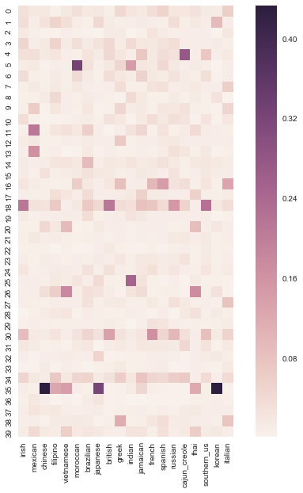

```python
# Визуализируйте матрицу
plot_matrix(tc_matrix)
```

Чем темнее квадрат в матрице, тем больше связь этой темы с данной кухней. Мы видим, что у нас есть темы, которые связаны с несколькими кухнями. Такие темы показывают набор ингредиентов, которые популярны в кухнях нескольких народов, то есть указывают на схожесть кухонь этих народов. Некоторые темы распределены по всем кухням равномерно, они показывают наборы продуктов, которые часто используются в кулинарии всех стран.

Жаль, что в датасете нет названий рецептов, иначе темы было бы проще интерпретировать...

### Заключение

В этом задании вы построили несколько моделей LDA, посмотрели, на что влияют гиперпараметры модели и как можно использовать построенную модель.